# Luminex, Moya-moya CSF samples

Cheng et al

Feb 2, 2019

# Overview: Analyze Luminex Run 1

The original data input has a duplicates.  
20-GS-IS18-33153172-151284-DX3 wells: D7,D6,  
23-GS-IS18-33153172-151284-DX3 wells: G7,G6,  
These two samples were averaged together. We think the tech might have run it twice because of free wells  
The averaging was done on the original excel in a seperate sheet.

For the final data we are going with log2 transform no normalization. We tested two other methods outlined by Rausch et al, 2016 ( log2 follow by quantile ) and ( asinh follow by loess ) however both did not perform as well as log2 and the best performer asinh follow by loess perform very similar. Thus to reduce data manipulation and ambiguity we are are going with just log2 not transform.

Diffrential differences was conducted with least mean square ( LMS ) with CHEX4 as a covariate. All p-value are corrected by tukey test.

# Key

Key

| Plate | group | ID | chex4 |
| --- | --- | --- | --- |
| 1 | Control | C12 | 4.988685 |
| 1 | Control | C4 | 4.768184 |
| 1 | Control | C18 | 4.569856 |
| 1 | Control | C25 | 4.754887 |
| 1 | Control | C19 | 4.807355 |
| 1 | Control | C17 | 4.906891 |
| 1 | Control | C7 | 4.807355 |
| 1 | Control | C16 | 5.011227 |
| 1 | Control | C15 | 4.807355 |
| 1 | Control | C26 | 5.139551 |
| 1 | Control | C29 | 4.930737 |
| 2 | Control | C27 | 5.108524 |
| 2 | Control | C21 | 4.807355 |
| 2 | Control | C9 | 4.988685 |
| 2 | Control | C24 | 4.700440 |
| 2 | Control | C8 | 4.882643 |
| 2 | Control | C31 | 4.977280 |
| 2 | Control | C6 | 4.906891 |
| 2 | Control | C13 | 4.965784 |
| 2 | Control | C1 | 4.930737 |
| 2 | Control | C22 | 5.033423 |
| 2 | Control | C20 | 4.700440 |
| 3 | Control | C11 | 4.882643 |
| 3 | Control | C5 | 4.820179 |
| 3 | Control | C3 | 4.754887 |
| 3 | Control | C14 | 4.686501 |
| 3 | Control | C23 | 4.918863 |
| 3 | Control | C2 | 4.754887 |
| 3 | Control | C30 | 5.228819 |
| 3 | Control | C10 | 4.727920 |

[output cut: 73 more lines]

* Chex4 is included to show non-specific binding

# Density plot

shows that log2 transformation normalizes the values and importantly three groups have similar shape and values.

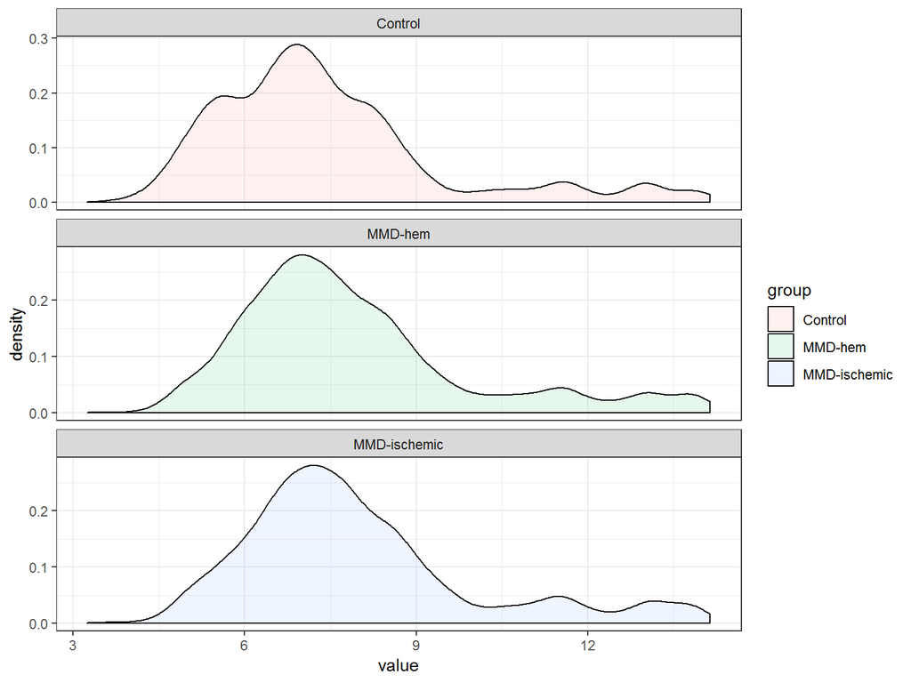

# boxplot

there were no apparent outlier sample

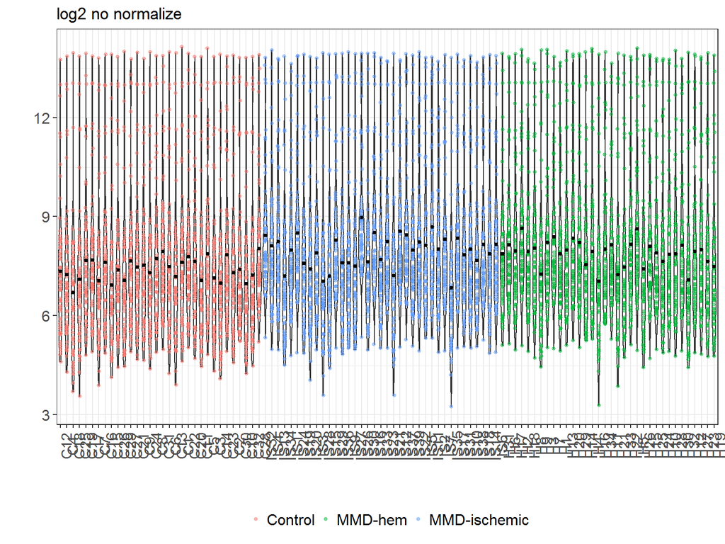

# PCA Unsupervised

Here we see that Dimension 1 explains about 61% of the variance. There are not clear grouping there however there is a slight pattern between the groups.

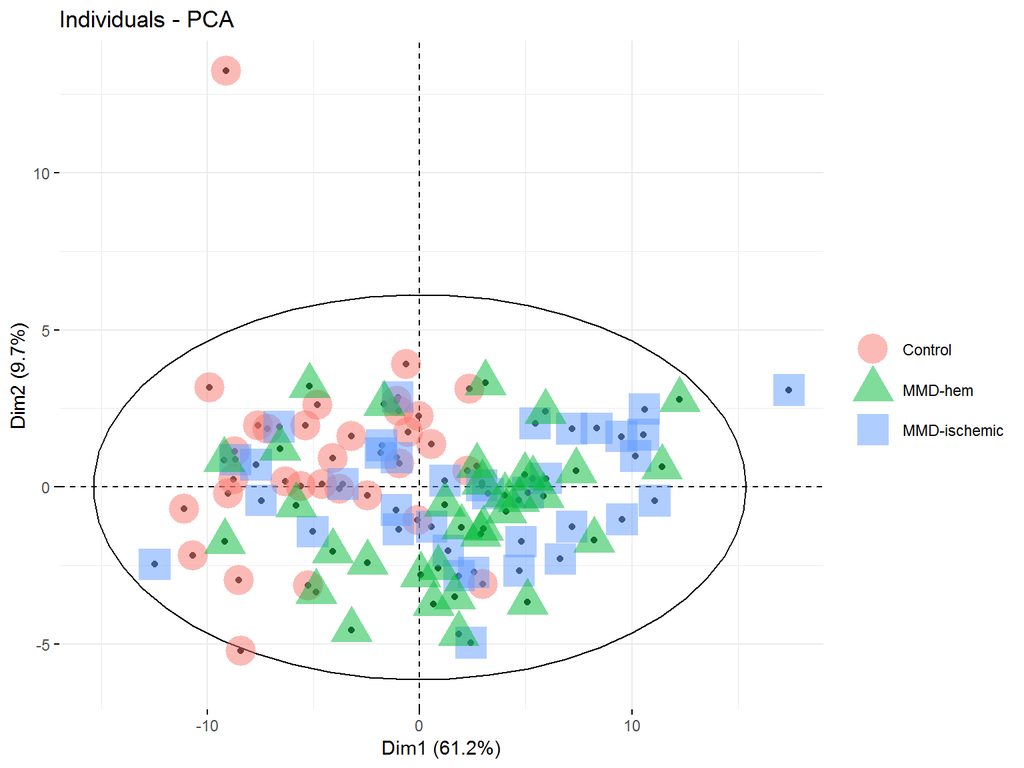

# Unsupervised Hierarchical clustering with euclidean distance using the Ward.2 method

This is easier to see and again, we see a slight grouping of the control group and possibly the two MMD subgroups. This is not perfect however given the small protein set and the nature of the experimental design and workflow its quite good. Although there are only three groups Gap statistics seem to indicate that there are between 3-4, thus we highlight this in the HR below. The side bar color codes the three groups.

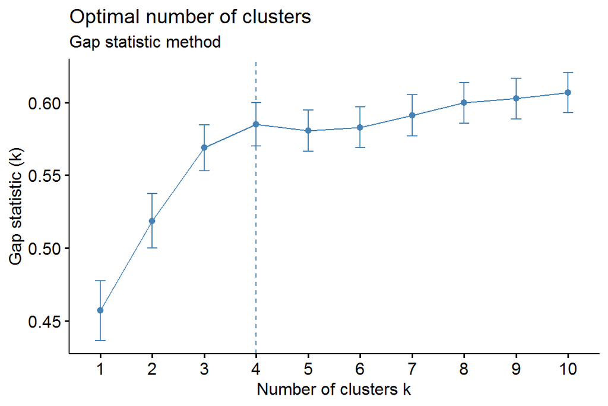

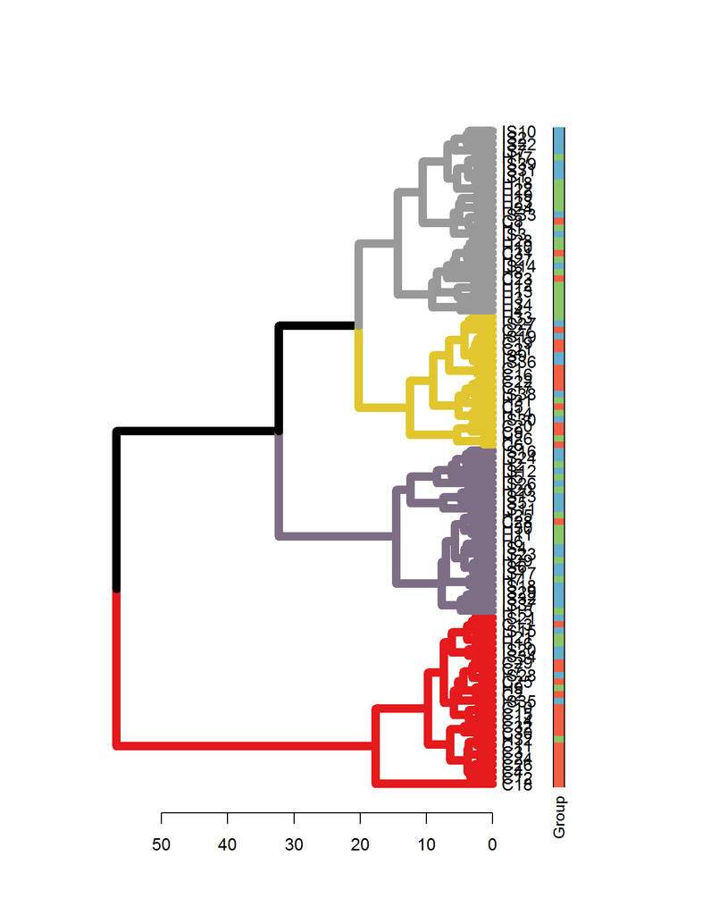

# Venn Diagram

Comparing Differential p < .05 from both groups.  
Both ischemic vs control and hemorrhagic vs control appears to be very similar

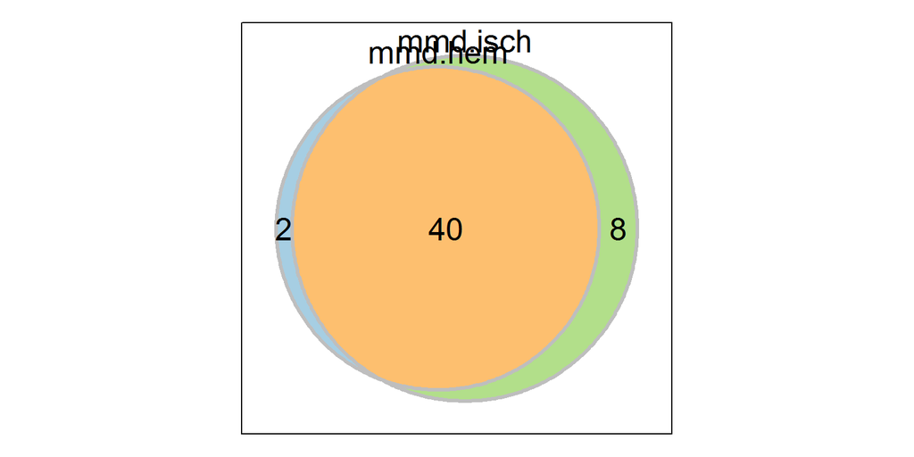

# Below are a few peptides with the highest fold change and significant

Notice how small the differences are. We need to look at the literature or ask how luminex works.

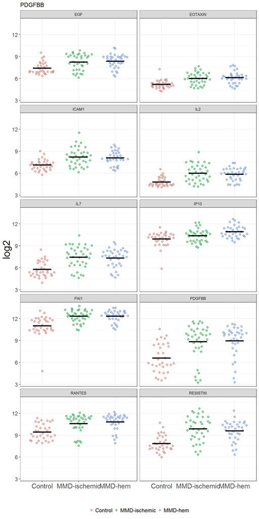

# Supervised Hierarchical clustering with euclidean distance using the Ward.2 method

We used genes that were signficant in both groups

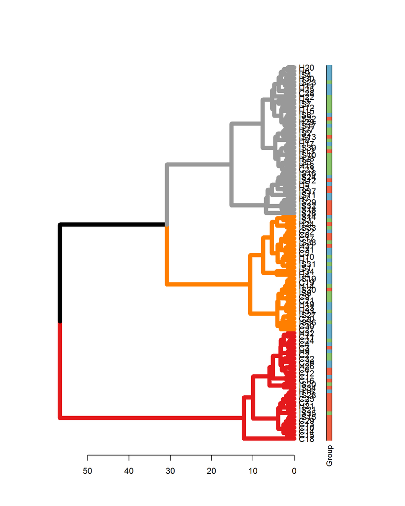

# Post plots on hemorrhagic group

[interactive chart not shown]

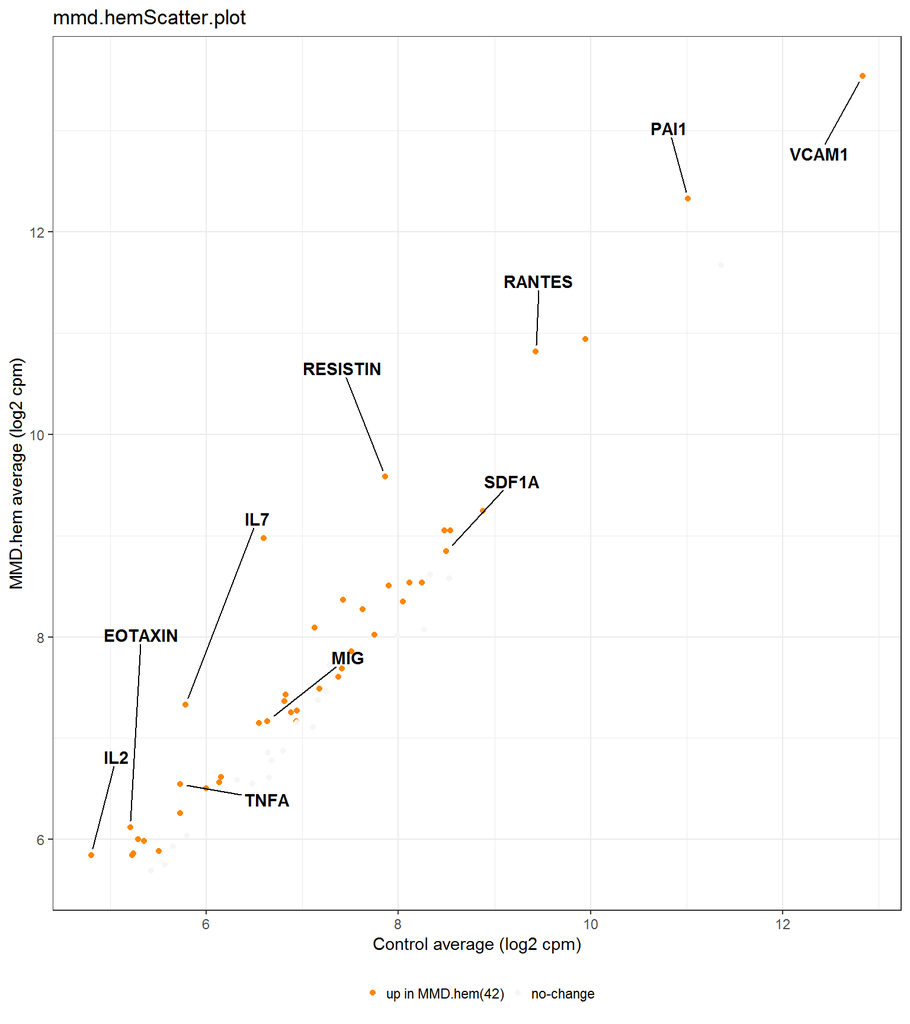

# Post plots on ischemic group

[interactive chart not shown]

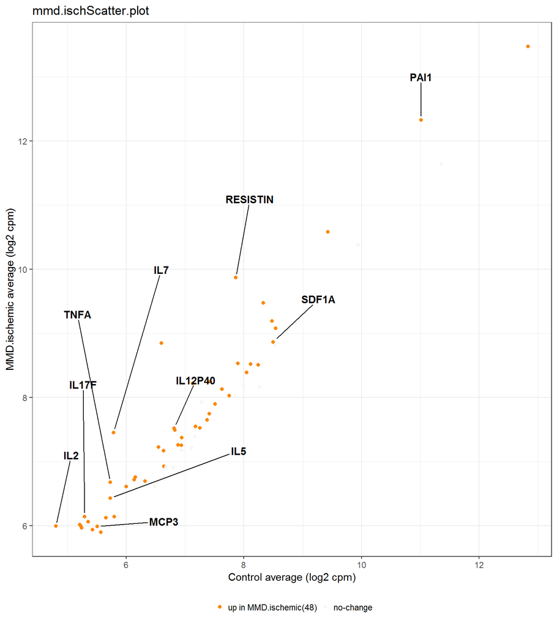

# Displaying some of the more interesting KEGG pathways. Please see the excel sheet for more info

- genes are annotted as long as p< .05
- fold changes are color coded
- Keep in mind that there are only a few genes in the dataset so pathways analysis is a bit odd.

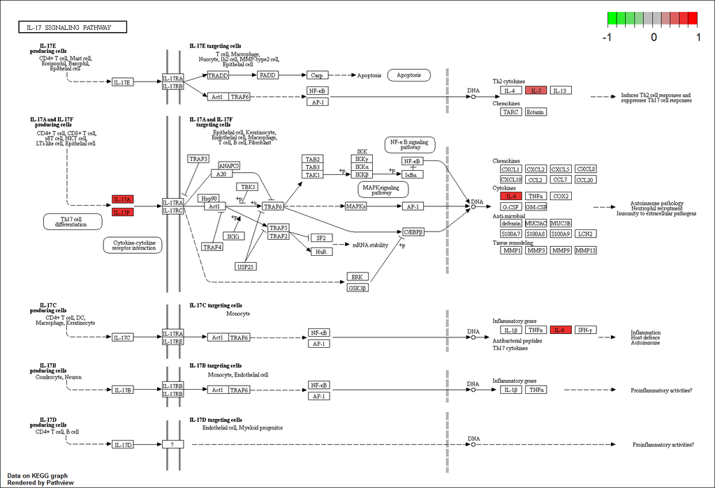

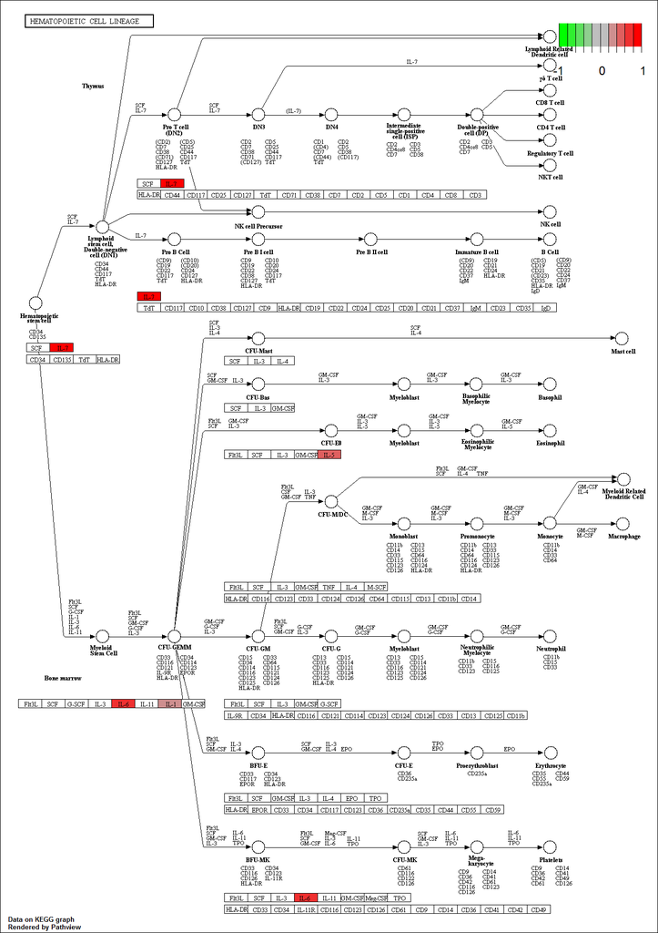